# Cluster analysis

Gavin Simpson

September 19, 2020

# Abstract

This practical will use diatom and hydro-chemistry for a series of 30 ponds and pools from Southern England; including hierarchical, *k*-means and fuzzy clustering techniques. The ponds data-set consists of mean annual chemistry for 30 lowland ponds and pools in south-east England spanning a range of water chemistry along a total phosphorus (TP) gradient. In addition, diatom data from the surface sediments in these ponds and pools are available. These chemistry and diatom data were collected as part of a surface-sediment diatom – water chemistry data set used to generate a transfer function for inferring past TP values from fossil diatom assemblages preserved in lake sediment cores.

# Tasks

1. Use R to perform a nearest neighbour, furthest neighbour, unweighted group average, weighted group average and minimum variance cluster analysis of the standardised water chemistry, and compare the resulting classifications;
2. Perform a *k*-means cluster analysis of the standardised water chemistry data and compare this classification with the agglomerative methods used in 1;
3. Perform a cluster analysis of the Vltava river valley data

# Hierarchical agglomerative cluster analysis

Hierarchical agglomerative cluster analysis methods start with all samples in separate clusters and sequentially fuse together the two most similar clusters until all samples are in a single cluster. A variety of measures of similarity (distance) (using dissimilarity or distance coefficients) can be employed as can a range of different ways in which the clusters are fused (e.g. single link, group average link, minimum variance method).

The functions `hclust()`, and `agnes()` (in package `cluster`) are the two standard functions for performing hierarchical agglomerative cluster analysis in R. The `dist()` function is used to create distance matrices using a variety of distance (or dissimilarity) coefficients. First, read in the **ponds** data set:

```r
ponds_url <- "https://bit.ly/pondsfull"
ponds <- read.csv(url(ponds_url))
names(ponds)
```

```
##  [1] "AC001A"       "AC013A"       "AC013E"       "AM011A"       "AM012A"
##  [6] "AS001A"       "AU002A"       "AU003B"       "CC001A"       "CC002A"
## [11] "CC9997"       "CM004A"       "CO001A"       "CY002A"       "CY003A"
## [16] "CY009A"       "CY011A"       "FR001A"       "FR002A"       "FR002C"
## [21] "FR006A"       "FR006E"       "FR009B"       "FR018A"       "FR019A"
## [26] "GO013A"       "NA004A"       "NA007A"       "NA022A"       "NA042A"
## [31] "NA114A"       "NI009A"       "NI014A"       "NI015A"       "NI083A"
## [36] "NI196A"       "NI9969"       "NI9971"       "OP001A"       "ST001A"
## [41] "ST002A"       "ST010A"       "SU016A"       "SY002A"       "SY003A"
## [46] "SY003C"       "SY010A"       "UN9992"       "pH"           "Conductivity"
## [51] "Alkalinity"   "TP"           "SiO2"         "NO3"          "Na"
## [56] "K"            "Mg"           "Ca"           "Cl"           "SO4"
## [61] "Chla"         "Secchi"       "Maxdepth"
```

```r
rownames(ponds)
```

```
##  [1] "4"   "7"   "31"  "34"  "37"  "42"  "50"  "53"  "57"  "58"  "65"  "69"
## [13] "73"  "74"  "76"  "79"  "82"  "83"  "85"  "86"  "98"  "100" "101" "105"
## [25] "107" "108" "112" "113" "114" "120"
```

```r
str(ponds)
```

```
## 'data.frame':    30 obs. of  63 variables:
##  $ AC001A      : num  0 0.36 0.9 0.17 0 ...
##  $ AC013A      : num  0.55 3.4 1.08 0.52 6.84 ...
##  $ AC013E      : num  0 0 0 0 0 0 0 0 0 0 ...
##  $ AM011A      : num  0.74 1.07 0.9 0.69 2.54 0 0 0.94 0.34 0.34 ...
##  $ AM012A      : num  0.92 8.05 5.39 0.35 2.34 0.73 0 0 0.34 0 ...
##  $ AS001A      : num  1.66 0.36 0 0 0.19 0.36 2.4 2.83 0 1.18 ...
##  $ AU002A      : num  4.6 0 0 0 0 ...
##  $ AU003B      : num  0 0 0 0 0 0 0 0 0 0 ...
##  $ CC001A      : num  0 2.15 0 9.69 0 0 0.2 0 0 0 ...
##  $ CC002A      : num  0 3.4 0.18 7.96 0 0 0.2 2.26 0 0 ...
##  $ CC9997      : num  0 0 0.18 15.23 0 ...
##  $ CM004A      : num  0 0 0 0 0 0 0 0 0 0 ...
##  $ CO001A      : num  0.18 3.94 0.72 0.52 2.15 0.91 2.4 0 0 4.06 ...
##  $ CY002A      : num  1.11 1.97 0 3.46 0.59 ...
```

[output cut: 49 more lines]

The `ponds` object you have just created contains observations on 30 ponds. Columns 1 through 48 of the `ponds` object contain the diatom counts of surface samples taken from each of the 30 ponds. The remaining columns contain the mean water chemistry data for each pond taken over the period represented by the diatom surface samples.

For the sake of simplicity during the remainder of the practical, we should subset `ponds` into a new object containing just the standardised water chemistry data. As its name suggests, the `subset()` function can be used to return a subset of a data frame. The `scale()` function ca be used to center (using the `center` argument) or standardise (using the `scale` argument) the columns of a data frame or matrix.

```r
pondsenv <- subset(ponds, select = pH:Maxdepth)
pondsenv <- scale(pondsenv, scale = TRUE, center = FALSE)
```

```r
env.ed <- dist(pondsenv)
pond.slink <- hclust(env.ed, method = "single")
pond.slink
```

```
##
## Call:
## hclust(d = env.ed, method = "single")
##
## Cluster method   : single
## Distance         : euclidean
## Number of objects: 30
```

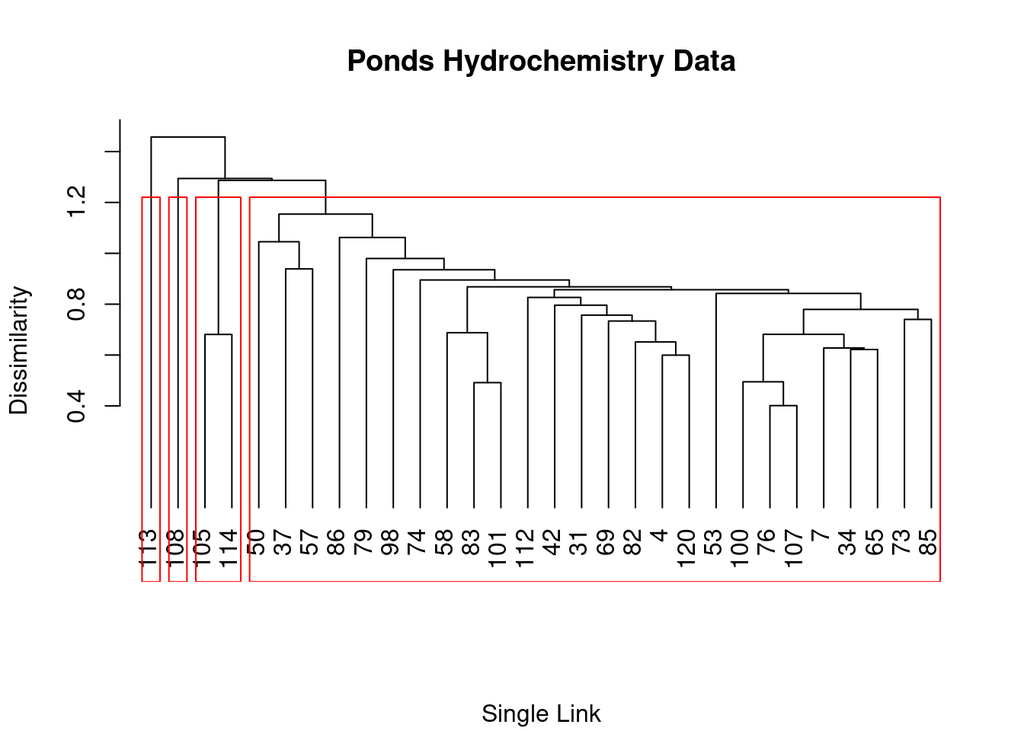

```r
plot(pond.slink, hang = -0.01, main = "Ponds Hydrochemistry Data",
     sub = "Single Link", ylab = "Dissimilarity", xlab = "")
rect.hclust(pond.slink, k = 4, border = "red")
```

```r
cor(coph.slink <- cophenetic(pond.slink), env.ed)
```

```
## [1] 0.5318913
```

In the first line, `dist()` is used to create a Euclidean distance matrix and store it in `env.ed` for use later in the practical when different clustering techniques are compared. `hclust()` performs the actual cluster analysis and requires a dissimilarity matrix from `dist()` and the clustering method to use to be given as arguments. The resulting `pond.slink` object contains the results needed to produce the dendrogram of the cluster analysis, but in keeping with R’s philosophy, only a brief summary of the object is presented when the object’s name is entered at the prompt.

The dendrogram of the cluster analysis is produced using `plot()`, with the `hang` argument instructing the plot method to draw the labels of the nodes of the dendrogram at the baseline of the plot. `rect.hclust()` is used to cut the dendrogram into *k* clusters (in this case 4) and then draw rectangles around the resulting *k* clusters on the dendrogram. Finally, the cophenetic correlation is calculated, using the `cophenetic()` function to first generate the cophenetic distances between ponds from the dendrogram [^1], and then the `cor()` function to calculate the Pearson product moment correlation between the original Euclidean distances and the cophenetic distances. The cophenetic correlation is one measure of how well the dendrogram represents the original distance matrix and therefore, how well it represents the real distance between samples.

An alternative way of visualising how faithfully a dendrogram represents the original dissimilarity matrix is via a Shepard-like plot. In a Shepard-like plot, the original distances (or dissimilarities) are plotted on the *x*-axis with the corresponding cophenetic distances plotted on the *y*-axis. A one to one line is drawn through the points to aid interpretation; deviations from the one to one line indicate how faithfully the original distances are represented from the dendrogram. If the dendrogram were able to fully represent the original distances, all the points would fall on the one to one line.

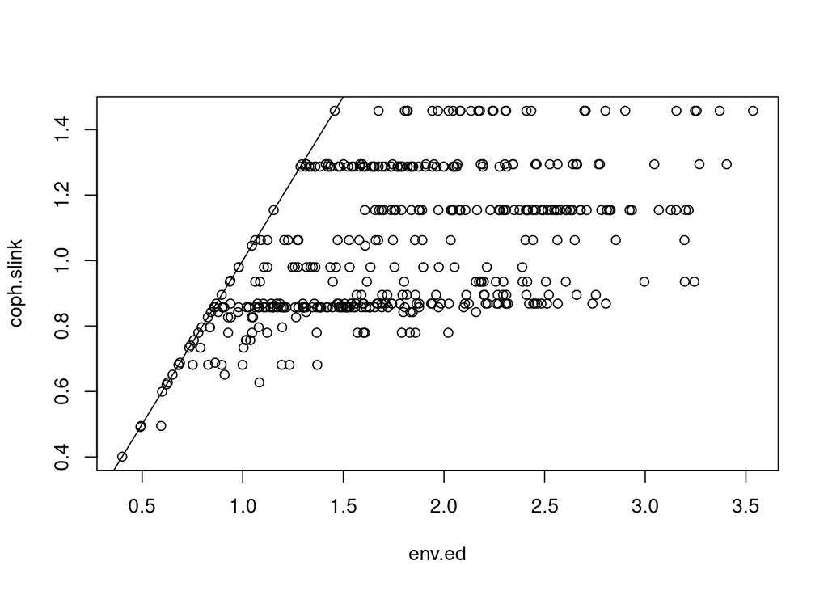

```r
plot(env.ed, coph.slink)
abline(a = 0, b = 1)
```

**What does the Shepard-like plot indicate about the faithfulness of the nearest neighbour dendrogram in representing the original Euclidean distances?**

**Repeat the above commands to perform the remaining clustering methods on the `pondsenv` data set. The commands needed are reproduced below. Try to come to a consensus as to how many clusters there are in the water chemistry data.**

```r
# complete link
pond.clink <- hclust(env.ed, method = "complete")
plot(pond.clink, hang = -0.01, main = "Ponds Hydrochemistry Data",
     sub = "Complete Link", ylab = "Dissimilarity", xlab = "")
rect.hclust(pond.clink, k = 4, border = "red")
```

[output not shown]

```r
cor(coph.clink <- cophenetic(pond.clink), env.ed)
```

```
## [1] 0.6543283
```

```r
plot(env.ed, coph.clink)
abline(a = 0, b = 1)
```

[output not shown]

```r
# average link
pond.avg <- hclust(env.ed, method = "average")
plot(pond.avg, hang = -0.01, main = "Ponds Hydrochemistry Data",
     sub = "Average Link", ylab = "Dissimilarity", xlab = "")
rect.hclust(pond.avg, k = 4, border = "red")
```

[output not shown]

```r
cor(coph.avg <- cophenetic(pond.avg), env.ed)
```

```
## [1] 0.7093294
```

```r
plot(env.ed, coph.avg)
abline(a = 0, b = 1)
```

[output not shown]

```r
# Ward's minimum variance clustering
pond.min <- hclust(env.ed, method = "ward")
```

```
## The "ward" method has been renamed to "ward.D"; note new "ward.D2"
```

```r
plot(pond.min, hang = -0.01, main = "Ponds Hydrochemistry Data",
     sub = "Minimum Variance", ylab = "Dissimilarity", xlab = "")
rect.hclust(pond.min, k = 4, border = "red")
```

[output not shown]

```r
cor(coph.min <- cophenetic(pond.min), env.ed)
```

```
## [1] 0.5672972
```

```r
plot(env.ed, coph.min)
abline(a = 0, b = 1)
```

[output not shown]

```r
# weighted average link
require("cluster")
```

```r
pond.wavg <- agnes(env.ed, method = "weighted")
pond.wavg <- as.hclust(pond.wavg)
plot(pond.wavg, hang = -0.01, main = "Ponds Hydrochemistry Data",
     sub = "Weighted Average Link", ylab = "Dissimilarity", xlab = "")
rect.hclust(pond.wavg, k = 4, border = "red")
```

[output not shown]

```r
cor(coph.wavg <- cophenetic(pond.wavg), env.ed)
```

```
## [1] 0.7481309
```

```r
plot(env.ed, coph.wavg)
abline(a = 0, b = 1)
```

[output not shown]

The final method applied, weighted group average clustering, is not implemented in tbase R. Instead, the `agnes()` function from the `cluster` package is used. The `as.hclust()` function is used to convert the output from `agnes()` into a `hclust()` object.

All cluster methods are designed to find clusters in any given data-set and as such, it is important to produce a number of clusterings of a data-set using a range of cluster techniques to try to find some consensus or agreement between the results of the various techniques employed. There are a number of ways in which this can be done. One simple way is to calculate the cophenetic correlation between all available clusterings of a given data-set using the `cor()` function.

```r
cor(cbind(coph.slink, coph.clink, coph.avg, coph.wavg, coph.min, env.ed))
```

```
##            coph.slink coph.clink  coph.avg coph.wavg  coph.min    env.ed
## coph.slink  1.0000000  0.3545052 0.6246113 0.5416554 0.1905182 0.5318913
## coph.clink  0.3545052  1.0000000 0.7001381 0.8023645 0.4645943 0.6543283
## coph.avg    0.6246113  0.7001381 1.0000000 0.8110084 0.5285280 0.7093294
## coph.wavg   0.5416554  0.8023645 0.8110084 1.0000000 0.4231211 0.7481309
## coph.min    0.1905182  0.4645943 0.5285280 0.4231211 1.0000000 0.5672972
## env.ed      0.5318913  0.6543283 0.7093294 0.7481309 0.5672972 1.0000000
```

`cbind()` was used to bind each of the vectors of distances into a data frame object, because `cor()` expects to be passed a matrix like object as one of its arguments.

**Are any of the clusterings closely correlated with each other and with the original Euclidean distances?**

```r
# install.packages("e1071")
require(e1071)
mem.slink <- cutree(pond.slink, k = 4)
mem.clink <- cutree(pond.clink, k = 4)
mem.avg <- cutree(pond.avg, k = 4)
mem.wavg <- cutree(pond.wavg, k = 4)
mem.min <- cutree(pond.min, k = 4)
members <- cbind(mem.slink, mem.clink, mem.avg, mem.wavg, mem.min)
compareMatchedClasses(members)
```

```
## $diag
##      [,1]     [,2]      [,3]      [,4]      [,5]
## [1,]   NA 0.326087 0.5000000 0.4901961 0.3095238
## [2,]   NA       NA 0.5283019 0.5576923 0.4722222
## [3,]   NA       NA        NA 0.9666667 0.4166667
## [4,]   NA       NA        NA        NA 0.3846154
## [5,]   NA       NA        NA        NA        NA
##
## $kappa
##      [,1]       [,2]       [,3]       [,4]       [,5]
## [1,]   NA 0.03778677 0.09866667 0.09734513 0.03791469
## [2,]   NA         NA 0.21411625 0.26445264 0.27848101
## [3,]   NA         NA         NA 0.90936556 0.14864865
## [4,]   NA         NA         NA         NA 0.12359551
## [5,]   NA         NA         NA         NA         NA
##
## $rand
##      [,1]      [,2]      [,3]      [,4]      [,5]
## [1,]   NA 0.4347826 0.4977376 0.4839216 0.4367015
## [2,]   NA        NA 0.5776488 0.6010558 0.6111111
## [3,]   NA        NA        NA 0.9402299 0.4746032
## [4,]   NA        NA        NA        NA 0.3846154
## [5,]   NA        NA        NA        NA        NA
##
## $crand
##      [,1]       [,2]       [,3]      [,4]        [,5]
## [1,]   NA -0.0127354 0.08084006 0.0707203 -0.02605023
## [2,]   NA         NA 0.11487677 0.1617804  0.17221740
## [3,]   NA         NA         NA 0.8733483  0.10836604
## [4,]   NA         NA         NA        NA  0.02547242
## [5,]   NA         NA         NA        NA          NA
```

The first five lines all utilise the `cutree()` function to return the cluster membership of each sample when the dendrogram is cut into the specified *k* classes. In this case we have chosen to cut each dendrogram into *k* = 4 classes. In each case, `cutree()` returns a vector of class member ships (1 - 4 in our case). Cohen’s $\kappa$ is the percentage of data points (samples) in the same cluster adjusted for chance. The Rand index is also presented both unadjusted for and adjusted for chance.

**Do any of the classifications show any consensus as the the resulting clusterings of the water chemistry data?**

# *k*-means cluster analysis

Agglomerative cluster analysis methods impose a hierarchy of between-sample distances; a hierarchy that is unlikely to exist in reality, but one which helps reduce the computational effort required to produce a clustering of the samples. Alternative solutions to the computational effort are available that do not impose a hierarchy on the data-set being clustered. The *k*-means clustering algorithm partitions a data-set into an *a priori* defined number of clusters by minimising the total error sum of squares, $E_k^2$ (TESS), which is to say that the distances between cluster members and the cluster centroid are minimised. The algorithm is, to a certain degree, sensitive to initial positions of the centroids of the clusters, which can result in the algorithm converging to a local minimum. The inital starting positions for the centroids are specified by the user, so care must be taken to ensure that the algorithm doesn’t converge towards local minima.

Several solutions can be used to help avoid convergence towards local minima:

1. Provide an initial configuration based on an ecological hypothesis;
2. Provide an initial configuration corresponding to the results of a hierarchical cluster analysis;
3. Provide an initial configuration by choosing at random *k* samples from the total data-set to act as the *k* group centroids. It is important to remember that this solution may still lead to a local minimum. Therefore, this procedure should be repeated many (say 100) times each with a different set of random samples as the starting points. The solution that minimises $E_k^2$ should then be retained.

It is easy, using the `kmeans()` function in R to implement solutions two or three from the list above, and for the purposes of this practical, you will provide the *k*-means algorithm with an initial configuration based on one of the hierachical cluster analyses performed earlier. We proceed by loading the `MASS` package, and creating a temporary matrix containing the water chemistry data to assist in calculating the initial starting configuration, which is stored in `initial`.

```r
require(MASS) #returns TRUE if loaded or is available to load FALSE if not
pondsenv.mat <- as.matrix(pondsenv)
# initial <- tapply(pondsenv.mat, list(rep(cutree(pond.avg, k = 4),
#     ncol(pondsenv.mat)), col(pondsenv.mat)),
# mean)
# dimnames(initial) <- list(NULL, dimnames(pondsenv.mat)[[2]])
# initial

initial <- aggregate(pondsenv ~ cutree(pond.avg, k = 4), FUN = mean)[, -1]
initial
```

```
##          pH Conductivity Alkalinity        TP      SiO2        NO3        Na
## 1 0.9906810    0.9881786  0.7738583 0.9732949 0.8987840  0.2763468 0.9882921
## 2 0.9686033    0.9498077  0.8444599 0.9718913 1.2580812  2.1319248 0.8700127
## 3 0.8783098    0.9307489 -0.5210372 0.9059333 1.0425081  1.5048369 1.0240844
## 4 1.0084576    0.9965745  0.6618439 0.9435906 0.5747634 -0.4682216 0.9526573
##           K        Mg        Ca        Cl       SO4      Chla    Secchi
## 1 0.9939912 0.9867959 0.9873855 0.9878328 0.9893787 0.9851775 0.8660565
## 2 0.8245920 0.8838306 0.9845333 0.8653552 0.8892995 0.7244555 1.2139745
## 3 0.9026149 0.9959402 0.8782816 1.0343345 0.9224448 0.9179478 0.6075038
## 4 1.0473468 0.9743230 1.0291234 0.9851449 1.0873895 0.4719017 1.6520901
##    Maxdepth
## 1 0.8930688
## 2 0.6140988
## 3 0.9644373
## 4 2.3653447
```

Now that we have calculated the initial starting configuration, we can proceed with the *k*-means clustering:

```r
ponds.km <- kmeans(pondsenv, centers = initial)
ponds.km
```

```
## K-means clustering with 4 clusters of sizes 10, 7, 6, 7
##
## Cluster means:
##          pH Conductivity Alkalinity        TP      SiO2          NO3        Na
## 1 1.0147997    1.0174257  1.1395204 0.9909872 0.9547134 -0.092901819 1.0024274
## 2 1.0070371    1.0033378  1.0986669 1.1009471 1.1024407  0.902807066 0.9912853
## 3 0.9738466    0.9511577  0.5986458 0.8716487 0.9580308  1.708050113 0.9019637
## 4 0.9152708    0.9313164 -0.2788570 0.8834023 0.7132049 -0.009911867 0.9935459
##           K        Mg        Ca        Cl       SO4      Chla    Secchi
## 1 1.0415040 0.9974897 1.0099982 1.0017756 1.0059339 0.9614444 1.1044150
## 2 1.0289529 0.9791206 1.0101287 0.9802753 1.0180834 1.2774124 0.5221512
## 3 0.8158069 0.9388798 0.9745891 0.9090489 0.9306542 0.7267176 1.2101862
## 4 0.9527984 0.9769680 0.9168744 1.0034129 0.9393455 0.7441124 0.7620074
##    Maxdepth
## 1 1.1229066
## 2 0.7948381
## 3 0.7679073
## 4 0.8813988
##
## Clustering vector:
##   4   7  31  34  37  42  50  53  57  58  65  69  73  74  76  79  82  83  85  86
##   1   2   1   2   3   1   3   4   3   4   2   1   4   4   2   1   1   4   4   1
##  98 100 101 105 107 108 112 113 114 120
##   2   2   4   3   2   3   1   1   3   1
##
## Within cluster sum of squares by cluster:
## [1] 7.632418 3.236025 6.381747 4.382761
##  (between_SS / total_SS =  58.5 %)
##
## Available components:
##
## [1] "cluster"      "centers"      "totss"        "withinss"     "tot.withinss"
## [6] "betweenss"    "size"         "iter"         "ifault"
```

The `cluster` component of `ponds.km` contains the cluster membership for each of the 30 ponds. The `centers` component contains the water chemistry values for the cluster centers, whilst the `withinss` and `size` components contains the within cluster sum of squares (the sum of the distances of each cluster member to the cluster center, the error) and the number of objects within each of the clusters respectively.

As the *k*-means method does not utilise a hierarchy in the analysis it is not possible to view the results of a *k*-means clustering in dendrogram form. An alternative is to plot the data and associated clustering on a biplot of the original data. The biplot could be produced using principal co-ordinates analysis (PCoA), non-metric multi-dimensional scaling (NMDS) or, as we shall now show, principal components analysis (PCA). Enter the following code chunk to display the results of the *k*-means clustering (after `identify()` you will need to click on the plotted points to identify them, end with a right click):

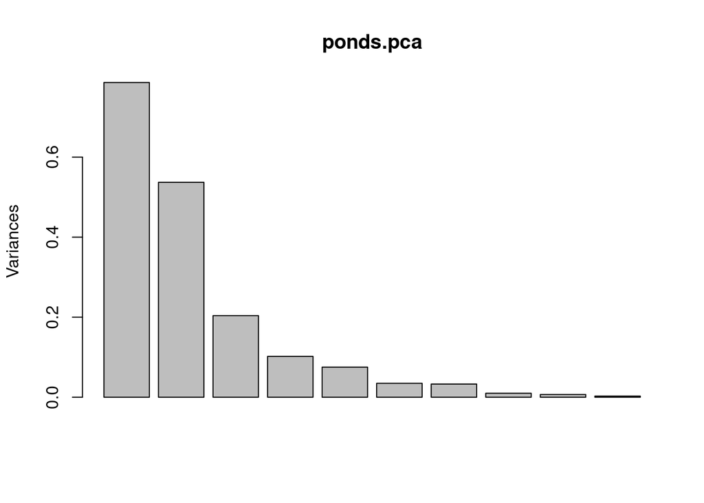

```r
ponds.pca <- prcomp(pondsenv)
screeplot(ponds.pca)
```

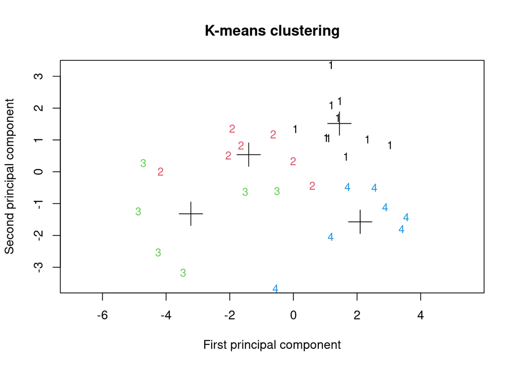

```
## integer(0)
```

```r
ponds.pred <- predict(ponds.pca, newdata = pondsenv)
dimnames(ponds.km$centers)[[2]] <- dimnames(pondsenv)[[2]]
pond.kmcenters <- predict(ponds.pca, ponds.km$centers)
eqscplot(ponds.pred[, 1:2], type = "n", xlab = "First principal component",
      ylab = "Second principal component", main = "K-means clustering")
text(ponds.pred[, 1:2], labels = ponds.km$cluster, cex = 0.9,
      col = ponds.km$cluster)
points(pond.kmcenters[, 1:2], pch = 3, cex = 3)
identify(ponds.pred[, 1:2], cex = 0.5)
```

# Canine data

```r
canine <- read.csv(url("https://bit.ly/canine-data"))
head(canine)
```

```
##           Group MandibleB MandibleH MolarLen MolarB Molar13 Premolar14
## 1    Modern dog       9.7      21.0     19.4    7.7    32.0       36.5
## 2 Golden jackal       8.1      16.7     18.3    7.0    30.3       32.9
## 3  Chinese wolf      13.5      27.3     26.8   10.6    41.9       49.1
## 4   Indian wolf      11.5      24.3     24.5    9.3    40.0       44.6
## 5          Cuon      10.7      23.5     21.4    8.5    28.8       37.6
## 6         Dingo       9.6      22.6     21.1    8.3    34.4       43.1
```

```r
rownames(canine) <- canine[, 1]
canine <- canine[, -1]
canine
```

```
##                 MandibleB MandibleH MolarLen MolarB Molar13 Premolar14
## Modern dog            9.7      21.0     19.4    7.7    32.0       36.5
## Golden jackal         8.1      16.7     18.3    7.0    30.3       32.9
## Chinese wolf         13.5      27.3     26.8   10.6    41.9       49.1
## Indian wolf          11.5      24.3     24.5    9.3    40.0       44.6
## Cuon                 10.7      23.5     21.4    8.5    28.8       37.6
## Dingo                 9.6      22.6     21.1    8.3    34.4       43.1
## Prehistoric dog      10.3      22.1     19.1    8.1    32.2       35.0
```

# Vltava river valley forest vegatation

Vegetation plots, located at even distances along transects following the steep valley slopes of Vltava river valley, collected during 2001-2003. Each transect starts at the valley bottom and ends up at the upper part of the valley slope. Altogether 97 plots located in 27 transects were collected, each of the size 10x15 m. In each plot, all tree, shrub and herb species were recorded and their abundances were estimated using 9-degree ordinal Braun-Blanquette scale (these values were consequently transformed into percentage scale).

```r
v_url <- "https://bit.ly/vltava-spp"
vltava <- read.delim (url(v_url), row.names = 1)
head(vltava)
```

[output not shown]

[^1]: The distances are stored in `coph.slink` for later use. This illustrates a useful feature of the R language; namely, we do not need to create an object before using it with separate commands. Here, the `coph.slink` object is both created and used as an argument to `cor()` in a single line of code